# CFA mit kategoralen Indikatoren (ML vs. WLSMV)

Forschungsmethoden Strukturgleichungsmodelle SS 2026

Clara Schubert und Anna Mockenhaupt

## Fragestellung:

In der Psychologie werden Likert-Skalen (z.B. 1-5 oder 1-6) routinemäßig als **kontinuierlich** behandelt.

Aber sind sie das wirklich?

Macht es einen Unterschied, ob Items als kontinuierlich (ML-Schätzung) oder als ordinal (WLSMV-Schätzung) behandelt werden?

## Der Datensatz mit dem wir arbeiten:

**psych::bfi** (R-Paket `psych`, N ≈ 2800, 25 Items, 6-stufige Likert-Skala)

Die Big Five sind dort über die Itemnamen codiert, mit 5 Items:

**A** = Agreeableness

**C** = Conscientiousness

**E** = Extraversion

**N** = Neuroticism

**O** = Openness

## Zwei unterschiedliche Schätzungen

**Sichtweise A: „Die Zahlen sind metrisch”**

**→ Maximum Likelihood:**

- behandelt die Daten wie *echte Messwerte* (z.B. Körpergröße in cm)
- berechnet Pearson-Korrelationen und schätzt darauf basierend das Modell

**Sichtweise B: „Die Zahlen sind nur Rangfolgen”**

**→ WLSMV = Weighted Least Squares Mean and Variance adjusted**

> „Hinter jeder Antwort steckt eigentlich eine *kontinuierliche, normalverteilte* **latente Variable**. Wir sehen nur, in welche Kategorie sie fällt.”
- berechnet **polychorische Korrelationen**: Das sind geschätzte Korrelationen zwischen den *latenten kontinuierlichen Variablen*, die hinter den Kategorien liegen.
- speziell für **ordinale Daten** entwickelt (z. B. Likert-Skalen wie beim BFI mit 1-6 Antwortskalen)

## Warum macht es einen Unterschied?

Wenn wir Korrelationen zwischen Items berechnen, dann…

- **unterschätzt** die **Pearson-Korrelation (ML)** den **wahren Zusammenhang**, besonders wenn Items schief verteilt sind oder wenige Kategorien haben
- die **Polychorische Korrelation (WLSMV)** **korrigiert** dafür und schätzt den „wahren” Zusammenhang hinter den Kategorien

**Wann sollten wir welches Verfahren nutzen?**

| Skala | ML | WLSMV |
| --- | --- | --- |
| 1–2 Kategorien | schlecht | gut |
| 3–5 Kategorien | ok | besser |
| 6–7 Kategorien | oft akzeptabel | sehr gut |
| kontinuierlich | ideal | nicht nötig |

## Systematischer Vergleich

*Fit-Indizes der 5-Faktor-CFA: ML vs. WLSMV*

| Fit-Index | ML | WLSMV<sup>1</sup> |
| --- | --- | --- |
| χ² | 4674.263 | 6049.275 |
| CFI | 0.776 | 0.824 |
| TLI | 0.747 | 0.801 |
| RMSEA | 0.077 | 0.095 |
| SRMR | 0.072 | 0.083 |

<sup>1</sup> *Note.* CFI und TLI bei WLSMV basieren auf einem anderen Baseline-Modell als bei ML — ein direkter Vergleich ist nur eingeschränkt interpretierbar.

**χ²:** Prüft ob die *modellimplizierte Kovarianzmatrix* exakt *der empirischen entspricht.*

- Signifikant: Modell *weicht signifikan*t von den Daten *ab*
- Problem: Bei großen Stichproben fast immer signifikant

**CFI**: *Vergleicht* das Modell *mit dem* **Baseline-Modell** *(*also dem Moddell das *keine Zusammenhänge* zwischen den Variabnlen annimmt)

- Werte hängen davon ab,

```
-   wie gut das eigene Modell passt

-   wie schlecht das Baseline-Modell passt
```

- Wenn sich das Baseline-Modell zwischen Schätzverfahren unterscheidet (wie es bei einigen Implementierungen für ordinale Daten der Fall sein kann), können sich CFI und TLI ändern, selbst wenn das eigentliche Faktorenmodell gleich bleibt.
- < .90 = problematisch

[output not shown]

**TLI**: ähnlich wie CFI, aber “*bestraft*” *Modellkomplexität*

- Kann theoretisch >1 oder <0 werden
- ≥ .95 = guter Fit
- ≥ .90 = akzeptabel

| ML | WLSMV |
| --- | --- |
| .747 schlecht | .801 schlecht |

**RMSEA**: Misst, wie gut das Modell *pro Freiheitsgrad in der Population passen würde*. Berücksichtigt Modellkomplexität

- ≤ .05 = guter Fit
- .05–.08 = akzeptabel
- .08–.10 = mäßig
- .10 = schlechter Fit

| ML | WLSMV |
| --- | --- |
| .077 akzeptabel | .095 mäßig |

**SRMR:** Standardisiertes Mittel der Residuen zwischen beobachteten und modellimplizierten Korrelationen. Direkt interpretierbar als durchschnittliche Abweichung

- ≤ .08 = guter Fit
- ≤ .05 = sehr guter Fit

| ML | WLSMV |
| --- | --- |
| .072 akzeptabel | .083 kein guter Fit |

## Was das inhaltlich bedeutet:

Beide Schätzer zeigen schlechten Fit. Das Modell passt einfach nicht gut zu den Daten.

→ trotzdem ist **WLSMV *methodisch* angemessener** (weil die Daten ordinal sind)

Warum ist der Fit so schlecht?

- Die Big Five sind **nicht so trennscharf** wie angenommen
- **Querladungen**
- **Korrelierte Residuen**

  → Das Modell scheint *insgesamt zu restrikiv* zu sein

## Ladungen Vergleich

*Standardisierte Faktorladungen: ML vs. WLSMV*

| Item | Standardisierte Ladung ML | Standardisierte Ladung WLSMV<sup>1</sup> | \|Δ\| |  |
| --- | --- | --- | --- | --- |
| Agreeableness |  |  |  |  |
| A1_rev | 0.334 | 0.358 |  | 0.024 |
| A2 | 0.635 | 0.678 | 0.043 |  |
| A3 | 0.738 | 0.770 | 0.032 |  |
| A4 | 0.484 | 0.555 | 0.071 |  |
| A5 | 0.683 | 0.790 | 0.107 |  |
| Conscientiousness |  |  |  |  |
| C1 | 0.531 | 0.599 | 0.068 |  |
| C2 | 0.582 | 0.605 | 0.023 |  |
| C3 | 0.534 | 0.539 | 0.005 |  |
| C4_rev | 0.685 | 0.752 | 0.067 |  |
| C5_rev | 0.618 | 0.714 | 0.096 |  |
| Extraversion |  |  |  |  |
| E1_rev | 0.565 | 0.540 | 0.025 |  |
| E2_rev | 0.688 | 0.733 | 0.045 |  |
| E3 | 0.631 | 0.688 | 0.057 |  |
| E4 | 0.694 | 0.744 | 0.050 |  |
| E5 | 0.549 | 0.623 | 0.074 |  |
| Neuroticism |  |  |  |  |
| N1 | 0.811 | 0.863 | 0.052 |  |
| N2 | 0.798 | 0.826 | 0.028 |  |
| N3 | 0.721 | 0.738 | 0.017 |  |
| N4 | 0.571 | 0.704 | 0.133 |  |
| N5 | 0.506 | 0.559 | 0.053 |  |
| Openness |  |  |  |  |
| O1 | 0.564 | 0.655 | 0.091 |  |
| O2_rev | 0.390 | 0.437 | 0.047 |  |
| O3 | 0.726 | 0.825 | 0.099 |  |
| O4 | 0.240 | 0.168 | 0.072 |  |
| O5_rev | 0.457 | 0.478 | 0.021 |  |

<sup>1</sup> *Note.* Ladungen basieren auf dem standardisierten Lösungsvektor (std.all). WLSMV-Ladungen sind polychorische Korrelationsschätzungen und daher nicht direkt mit ML-Ladungen vergleichbar. |Δ| = absoluter Unterschied zwischen ML und WLSMV.

**|Δ|** = **absoluter Unterschied** zwischen ML und WLSMV

Aber die Ladungen *basieren auf unterschiedichen Schätzungen*

→ **nicht direkt miteinander vergleichbar**

Die Differenzspalte **|Δ|** zeigt uns:

welche Items *instabil* über Schätzer hinweg sind *nicht* wie groß der „wahre” Unterschied ist

## Wie sind die Ergebnisse zu interpretieren?

Was wir *nicht* sagen Können:

> „WLSMV schätzt die Ladung um .08 höher als ML.”

Was wir *schon* sagen können:

> „Items mit großen Differenzen reagieren stärker auf die Wahl des Schätzers.”

Konkret bedeutet das:

- `Kleine Differenz (< .05)` → Item verhält sich **robust**:

  egal ob ML oder WLSMV, die Ladung ist ähnlich stabil
- `Große Differenz (> .10)` → Das Item ist **empfindlich gegenüber der Schätzerannahme**. Das passiert typischerweise bei Items mit *starker Schiefe oder wenig Kategorienstreuung*

## Aufällige Items und was wir damit machen

Die meisten Differenzen sind klein bis mittel.

Fünf Items zeigen größere Differenzen:

- **A5: |Δ|= .107**
- C5_rev:|Δ|= .096
- O1: |Δ|= .091
- **N4: |Δ|= .133**
- O3: |Δ|= .099
- → **Verteilung** prüfen
- → je Faktor die **Polychorische** vs. **Pearson‑Korrelationen** vergleichen
- → **Modellvarianten** testen (z. B. Item entfernen oder korrelierte Residuen modellieren)

## Verteilung prüfen

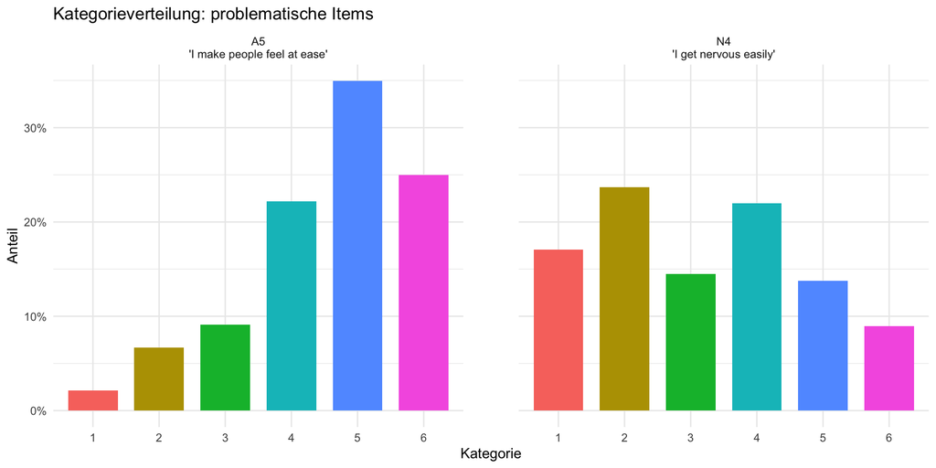

## Polychorische vs. Pearson Korrelation

```
          N1        N2        N3        N4        N5
N1 1.0000000 0.7642398 0.6075305 0.4369481 0.4196126
N2 0.7642398 1.0000000 0.5970472 0.4291399 0.3848587
N3 0.6075305 0.5970472 1.0000000 0.5643563 0.4703600
N4 0.4369481 0.4291399 0.5643563 1.0000000 0.4402615
N5 0.4196126 0.3848587 0.4703600 0.4402615 1.0000000
```

```
          N1        N2        N3        N4        N5
N1 1.0000000 0.7069810 0.5564251 0.3978058 0.3781264
N2 0.7069810 1.0000000 0.5491031 0.3915704 0.3506126
N3 0.5564251 0.5491031 1.0000000 0.5195043 0.4284187
N4 0.3978058 0.3915704 0.5195043 1.0000000 0.3976961
N5 0.3781264 0.3506126 0.4284187 0.3976961 1.0000000
```

## Einfluss auf Modell-Fit prüfen

**Interpretation:**

[output not shown]

- wenn N4 entfernt wird **steigen** alle Indizes **in die gewünschte Richtung**
- Besonders aufällig ist die **Verbesserung bei WLSMV**
- **ABER!** → das bedeutet nicht zwangsläufig, dass das Item aus dem Fragebogen entfernt werden sollte. Testentwickler müssen neben statistischen Kennwerten auch **theoretische Überlegungung, Inhaltsvalidität und die Vergleichbarkeit mit bestehenden Normen berücksichtigen**
- diese Ergebnisse sprechen dafür, dass **WLSMV als Schätzer für ordinal-skalierte Items günstiger ist**

## Faktorinterkorrelation vergleichen

```
                  Agrbln Cnscnt Extrvr Nrtcsm Opnnss
Agreeableness       1.00
Conscientiousness   0.34   1.00
Extraversion        0.68   0.35   1.00
Neuroticism        -0.22  -0.29  -0.23   1.00
Openness            0.31   0.30   0.45  -0.12   1.00
```

```
                  Agrbln Cnscnt Extrvr Nrtcsm Opnnss
Agreeableness       1.00
Conscientiousness   0.37   1.00
Extraversion        0.70   0.39   1.00
Neuroticism        -0.25  -0.31  -0.29   1.00
Openness            0.30   0.33   0.49  -0.13   1.00
```

Die Beziehungen zwischenn den Faktoren werden unter WLSMV teilweise (leicht) stärker geschätzt als unter ML

- Die **Faktorladungen** **reagieren** teilweise **deutlich** auf die Schätzerwahl.
- Die **Beziehungen** zwischen den *Big-Five-Faktoren* bleiben dagegen ziemlich **stabil**.

Die Wahl des Schätzers beeinflusst die Stärke der Schätzungen, aber nicht die grundlegende Struktur des Modells

## Take-Home-Message

1. Likert-Skalen sind nicht automatisch metrisch. Die Annahme “gleicher Abstände” wird oft verletzt. Dennoch wird in psychologischer Praxis ML meist als default verwendet
2. Es gibt keine One-size-fits-all-Lösung. Am besten beide Schätzer verwenden und konvergenz prüfen. Wenn sie sich unterschiden, deutet das darauf hin, dass Datenmerkmale (wie z.B. Schiefe) die Schätzung beeinflussen
3. Fit-Indizes sind nicht direkt vergleichbar: Unterschiedliche Korrelationsmatrizen, unterschiedliche Baseline-Modelle
4. Je weniger Kategorien, desto stärker die Verzerrung durch ML. Bei 6+ Kategorien und symmetrischer Verteilung sind die Unterschiede oft gering. ML ist dann oft ausreichend
5. WLSMV korrigiert dafür, indem es die latente kontinuierliche Variable hinter den Kategorien schätzt.
6. Die Schätzerwahl beeinflusst eure Ergebnisse. Deshalb: immer berichten, welchen Schätzer ihr verwendet habt und warum